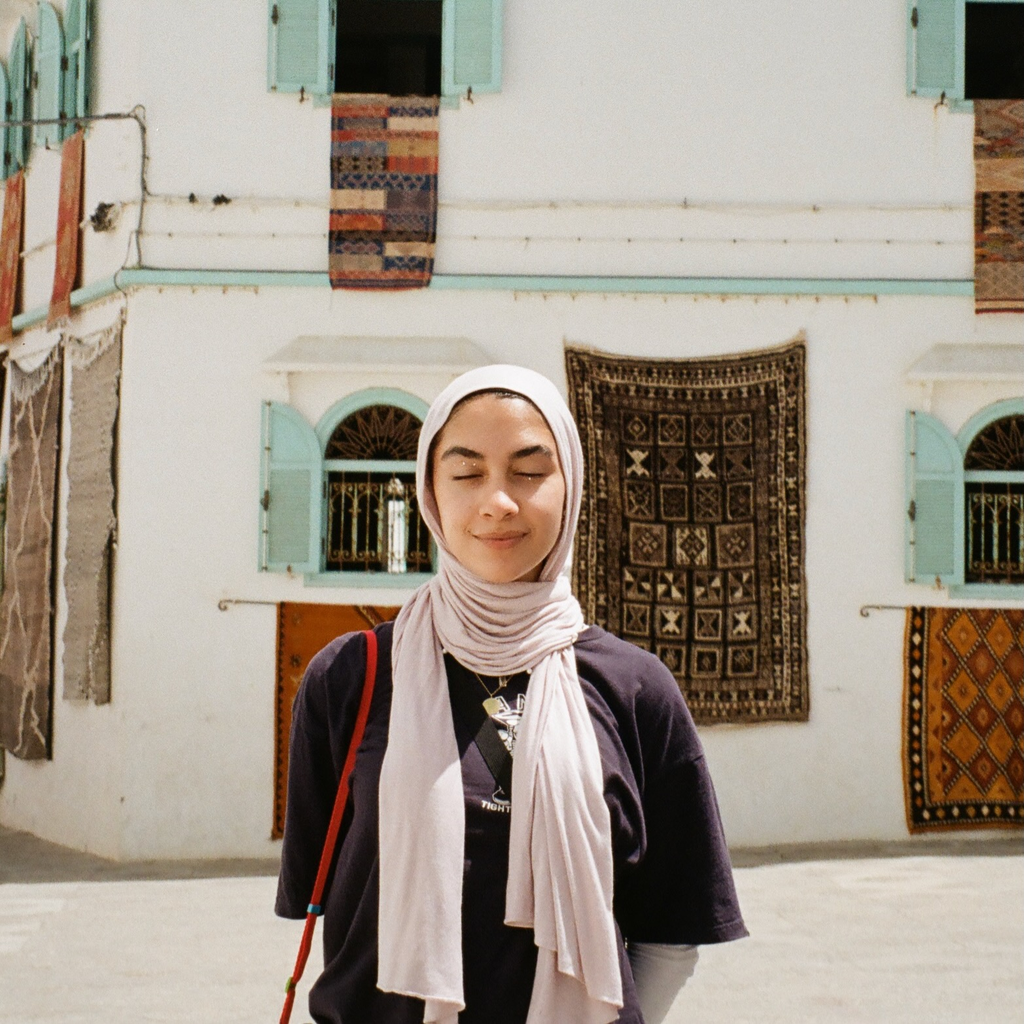

# Meriam Berka

## Bio

hello! My name is Meriam, I’m a second year MHS student in Epidemiology at the John Hopkins Bloomberg School of Public Health. I’m an aspiring social epidemiologist who’s interested in maternal and women’s health, my background is in sociology so I’m very interested in structural analyses of the causes of health inequity. I’m also a research assistant for the [Center for Indigenous Health](https://cih.jhu.edu) where I primarily use STATA for data cleaning and analysis work. I’ve tried to make the switch to R quite a few times on my own but intro R courses have been my Sisyphus’ boulder, the accountability and guidance of this class was a major motivation to take it.

## Some facts about me

**1.** I’m Moroccan! And a born Baltimorean but I grew up in Calgary, AB near the Rockies.

**2.** I’m a big hobbies person. I used to paint a lot and I got really into cooking over the pandemic, now I’m trying to learn how to sew.

**3.** I’m not a good critic because I like most things so I have a hard time choosing my favourite anything, but my top 3 played songs on spotify are [Tezeta](https://www.youtube.com/watch?v=Wy-v-FgiUD8), [Paper Bag](https://www.youtube.com/watch?v=BK30r_SIZ-g) and [Zina](https://www.youtube.com/watch?v=6-UOmjw9viQ)

**4.** I have a twin (fraternal), she just got married over the summer and we got to have the wedding in Morocco with all our family.

**5.** I was named “most likely to become a motivational speaker” in my senior yearbook which has (thankfully) proven to be totally inaccurate so far.

## Something interesting

I have too much school on my mind to think of anything good, here’s [an article](https://theconversation.com/you-dont-have-a-male-or-female-brain-the-more-brains-scientists-study-the-weaker-the-evidence-for-sex-differences-158005) I was just reading on how male and female brains aren’t really different. I think it’s a pretty poignant example of how cherry-picking and positive bias influences pop-science and conventional thinking.